# Homework

Wenluo ZHang

2024-12-05

# HW 1

## Exercise 3.4

The Rayleigh density [156, Ch. 18] is given by:
$$f(x) = \frac{x}{\sigma^2} e^{-x^2 / (2\sigma^2)}, \quad x \geq 0, \,
\sigma > 0.$$
Develop an algorithm to generate random samples from a Rayleigh$(\sigma)$ distribution. Generate Rayleigh$(\sigma)$ samples for several choices of $\sigma > 0$ and check that the mode of the generated samples is close to the theoretical mode $\sigma$ (check the histogram).

### Solution:

The CDF is
$$F(x) = 1 -
e^{-\frac{x^2}{2\sigma^2}}, \quad x \geq 0$$
Inverse function is
$$F^{-1}(u) = \sigma \sqrt{-2 \ln(1 - u)},
\quad u \in (0, 1)$$

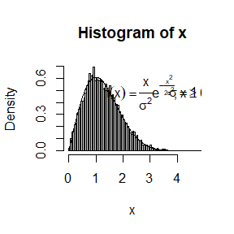

```r
n <- 10000
u <- runif(n)#generate random number
Rayleigh <- function(sigma){
  x <- sigma * sqrt(-2 * log(1-u)) #Inverse transform algorithm
  hist(x,breaks=100,prob = TRUE)#plot density

  #title
  usr <- par("usr")
  text(x = usr[2] - 0.3 * (usr[2] - usr[1]),
     y = usr[4] - 0.3 * (usr[4] - usr[3]),
     expression(f(x) == frac(x, sigma^2) * e^{-frac(x^2, 2 * sigma^2)} * "," ~ x >= 0 ~ ","))
  text(x = usr[2] - 0.13 * (usr[2] - usr[1]),
     y = usr[4] - 0.3 * (usr[4] - usr[3]),  substitute(sigma == sigma_val, list(sigma_val = sigma)))

  y <- seq(0, 100, .01)
  lines(y, (y / sigma^2) * exp(-y^2 / (2 * sigma^2))) # plot oracle density function
}
Rayleigh(1)
```

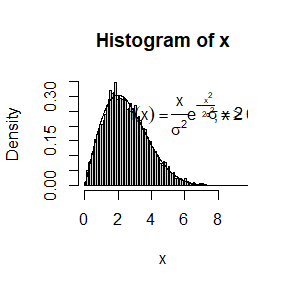

```r
Rayleigh(2)
```

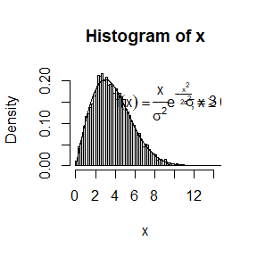

```r
Rayleigh(3)
```

We can find that the mode of the generated samples is close to the theoretical mode σ.

# HW 2

## Excercise 3.11

Generate a random sample of size 1000 from a normal location mixture. The components of the mixture have $N(0, 1)$ and $N(3, 1)$ distributions with mixing probabilities $p_1$ and $p_2 = 1 - p_1$.

Graph the histogram of the sample with the density superimposed, for $p_1 = 0.75$. Repeat with different values for $p_1$ and observe whether the empirical distribution of the mixture appears to be bimodal. Make a conjecture about the values of $p_1$ that produce bimodal mixtures.

### Solution:

First generate a random $a$ number between 0 and 1. If $a \leq p_1$, then generate $x$ with $N(0, 1)$ otherwise generate $x$ with $3+N(0,1)$.

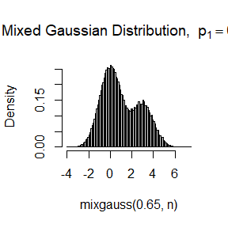

```r
p1 <- 0.25
n <- 100000

mixgauss <-function(p,n){
  x <- rep(0, n)
  for(i in 1:n){
    a <- runif(1) #generate random number
    if (a < p){  #check if a < p1
      x[i] <- rnorm(1)
    }
    else{
      x[i] <- 3+ rnorm(1)
    }
  }
  return(x)
}
#par(mfrow = c(2, 2))
hist(mixgauss(0.65,n),breaks=150,prob = TRUE,main = expression("Mixed Gaussian Distribution, " ~ p[1] == 0.65))
```

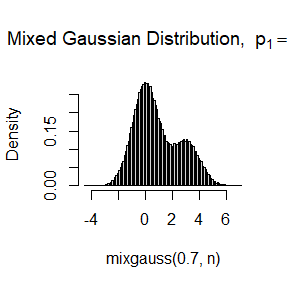

```r
hist(mixgauss(0.7,n),breaks=150,prob = TRUE,main = expression("Mixed Gaussian Distribution, " ~ p[1] == 0.7))
```

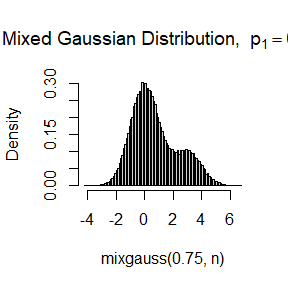

```r
hist(mixgauss(0.75,n),breaks=150,prob = TRUE,main = expression("Mixed Gaussian Distribution, " ~ p[1] == 0.75))
```

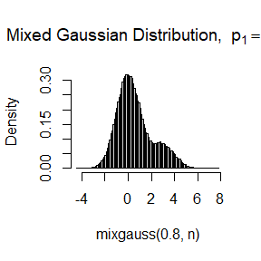

```r
hist(mixgauss(0.8,n),breaks=150,prob = TRUE,main = expression("Mixed Gaussian Distribution, " ~ p[1] == 0.8))
```

## Excercise 3.20

A compound Poisson process is a stochastic process $\{X(t), t \geq 0\}$ that can be represented as the random sum
$$X(t) = \sum_{i=1}^{N(t)} Y_i, \quad t \geq 0,$$
where $\{N(t), t \geq 0\}$ is a Poisson process and $Y_1, Y_2, \dots$ are i.i.d. and independent of $\{N(t), t \geq 0\}$.

Write a program to simulate a compound Poisson$(\lambda)$–Gamma process (where $Y$ has a Gamma distribution). Estimate the mean and variance of $X(10)$ for several choices of the parameters and compare with the theoretical values.

**Hint**: Show that:
$$E[X(t)] = \lambda t E[Y_1] \quad \text{and} \quad \text{Var}(X(t)) =
\lambda t E[Y_1^2].$$

### Solution:

```r
lambda = 0.5
alpha <-2
beta <- 2
X<- function(t){#generate compound Poisson process
  n = rpois(1,lambda*t)
  result = 0
  for (i in 1:n){
    result = result + rgamma(1,shape = alpha,rate = beta)
  }
  return(result)
}

n <- 10000
data <- rep(0, n)
for (i in 1:n){
  data[i] = X(10)
}
{
cat("When lambda = ",lambda,"alpha = ",alpha,"beta = ",beta,"\n")
cat("The mean of X(10) is", mean(data),"\n")
cat("The variance of X(10) is", var(data),"\n")
cat("λtE[Y_1] = ", lambda*10*alpha/beta,"\n")
cat("λtE[Y_1^2] = ", lambda*10*alpha*(beta+1)/beta^2,"\n\n")}
```

```
## When lambda =  0.5 alpha =  2 beta =  2
## The mean of X(10) is 4.99809
## The variance of X(10) is 7.488141
## λtE[Y_1] =  5
## λtE[Y_1^2] =  7.5
```

```r
#The second set of parameters
lambda = 1
alpha <-1
beta <- 2
data <- rep(0, n)
for (i in 1:n){
  data[i] = X(10)
}
{
cat("When lambda = ",lambda,"alpha = ",alpha,"beta = ",beta,"\n")
cat("The mean of X(10) is", mean(data),"\n")
cat("The variance of X(10) is", var(data),"\n")
cat("λtE[Y_1] = ", lambda*10*alpha/beta,"\n")
cat("λtE[Y_1^2] = ", lambda*10*alpha*(alpha+1)/beta^2,"\n\n")}
```

```
## When lambda =  1 alpha =  1 beta =  2
## The mean of X(10) is 4.957609
## The variance of X(10) is 4.872796
## λtE[Y_1] =  5
## λtE[Y_1^2] =  5
```

```r
#The third set of parameters
lambda = 1
alpha <-2
beta <- 0.5
data <- rep(0, n)
for (i in 1:n){
  data[i] = X(10)
}
{
cat("When lambda = ",lambda,"alpha = ",alpha,"beta = ",beta,"\n")
cat("The mean of X(10) is", mean(data),"\n")
cat("The variance of X(10) is", var(data),"\n")
cat("λtE[Y_1] = ", lambda*10*alpha/beta,"\n")
cat("λtE[Y_1^2] = ", lambda*10*alpha*(alpha+1)/beta^2,"\n\n")}
```

```
## When lambda =  1 alpha =  2 beta =  0.5
## The mean of X(10) is 40.08532
## The variance of X(10) is 240.9567
## λtE[Y_1] =  40
## λtE[Y_1^2] =  240
```

We can observe that the estimation is close to theoretical number, which follows the equation
$$E[X(t)] = \lambda
t E[Y_1] \quad \text{and} \quad \text{Var}(X(t)) = \lambda t E[Y_1^2].$$

## Excercise 5.4

Write a function to compute a Monte Carlo estimate of the Beta(3, 3) cdf, and use the function to estimate F(x) for x = 0.1, 0.2,…, 0.9. Compare the estimates with the values returned by the pbeta function in R

### Solution

Beta(3, 3)分布的累积分布函数（CDF）为：

$$F(x) = \int_0^x \frac{u^{2} (1-u)^{2}}{B(3, 3)} \, du \quad \text{for }
0 \leq x \leq 1$$
所以
$$F(x)=
\mathbb{E}_{U}[x\frac{U^{2} (1-U)^{2}}{B(3, 3)}], U\sim U(0,x)$$

```r
beta_cdf <- function(x,a,b){#模特卡罗模拟beta分布cdf
  m <- 1e4; u <- runif(m, min=0, max=x)
  estimation <- mean(x*u^2*(1-u)^2/beta(a,b))
  return (estimation)
}
for (x in seq(0.1, 0.9, 0.1)){
  cat("x=",x,"\n")
  cat("蒙特卡洛模拟累计分布函数值：",beta_cdf(x,3,3),"\n")
  cat("真实累计分布函数值：",pbeta(x,3,3),"\n")
}
```

```
## x= 0.1
## 蒙特卡洛模拟累计分布函数值： 0.008568807
## 真实累计分布函数值： 0.00856
## x= 0.2
## 蒙特卡洛模拟累计分布函数值： 0.05794065
## 真实累计分布函数值： 0.05792
## x= 0.3
## 蒙特卡洛模拟累计分布函数值： 0.1635116
## 真实累计分布函数值： 0.16308
## x= 0.4
## 蒙特卡洛模拟累计分布函数值： 0.3168619
## 真实累计分布函数值： 0.31744
## x= 0.5
## 蒙特卡洛模拟累计分布函数值： 0.4981067
## 真实累计分布函数值： 0.5
## x= 0.6
## 蒙特卡洛模拟累计分布函数值： 0.6877776
## 真实累计分布函数值： 0.68256
## x= 0.7
## 蒙特卡洛模拟累计分布函数值： 0.841028
## 真实累计分布函数值： 0.83692
## x= 0.8
## 蒙特卡洛模拟累计分布函数值： 0.9388768
## 真实累计分布函数值： 0.94208
## x= 0.9
## 蒙特卡洛模拟累计分布函数值： 1.003119
## 真实累计分布函数值： 0.99144
```

## Excercise 5.9

```r
n <- 10000
u <- runif(n)#generate random number

Rayleigh_1 <- function(sigma){
  x <- sigma * sqrt(-2 * log(1-u)) #Inverse transform algorithm
}
Rayleigh_antithetic <- function(sigma){ #generated by antithetic variables
  x <- sigma * sqrt(-2 * log(u))
}
Rayleigh_2 <- function(sigma){
  u <- runif(n)
  x <- sigma * sqrt(-2 * log(1-u))
}

data <- matrix(1:9, nrow = 3, ncol = 3)
rownames(data) <- c('var((X + X\')/ 2)' , 'var((X_1 + X_2)/ 2)', 'reduction')
colnames(data) <- c("σ=1", "σ=2", "σ=3")
for (i in 1:nrow(data)){
  for (j in 1:ncol(data)){
    if (i == 1){
    data[i,j] <- var(Rayleigh_1(j)+Rayleigh_antithetic(j))/4}
    if (i == 2){
    data[i,j] <- var(Rayleigh_1(j)+Rayleigh_2(j))/4}
    if (i == 3){
    data[i,j] <- 1-data[1,j]/data[2,j]}
  }
}
data
```

```
##                            σ=1        σ=2        σ=3
## var((X + X')/ 2)    0.01106875 0.04427502 0.09961879
## var((X_1 + X_2)/ 2) 0.21362363 0.85566445 1.89664723
## reduction           0.94818572 0.94825656 0.94747637
```

方差减少了95%

## Excercise 5.13

Find two importance functions $f_1$ and $f_2$ that are supported on $(1, \infty)$ and are `close’ to
$$g(x) = \frac{x^2}{\sqrt{2\pi}} e^{-x^2/2}, \quad x > 1.$$
Which of your two importance functions should produce the smaller variance in estimating
$$\int_{1}^{\infty} \frac{x^2}{\sqrt{2\pi}} e^{-x^2/2} \, dx$$
by importance sampling? Explain.

### Solution

设
$$f_1(x) = e^{-(x - 1)}, \quad x > 1,$$
为偏移的指数分布
$$f_2(x) = \frac{2}{\sqrt{2\pi}} e^{-\frac{(x - 1)^2}{2}}, \quad x > 1,$$
为半正态分布

```r
f_1 <- function(x){#指数分布
  return (exp(-(x-1)))
}
f_2 <- function (x){#半正态分布
  return(2/sqrt(2*pi)*exp(-(x-1)^2/2))
}
g <- function (x){
  return (x^2/sqrt(2*pi)*exp(-x^2/2))
}


n <- 1000000
x_1 <- rexp(n, 1) +1
x_2 <- abs(rnorm(n,0)) +1
{
  cat("通过f_1的估计",mean(g(x_1)/f_1(x_1)),'\n')
  cat("通过f_2的估计",mean(g(x_2)/f_2(x_2)),'\n')
  cat('f_1/‖f_1‖-g/‖g‖的L1范数',integrate(function(x) abs(f_1(x)-g(x)/integrate(function(x) g(x), lower = 1, upper = Inf)$value), lower = 1, upper = Inf)$value,'\n')
  cat('f_2/‖f_2‖-g/‖g‖的L1范数',integrate(function(x) abs(f_2(x)-g(x)/integrate(function(x) g(x), lower = 1, upper = Inf)$value), lower = 1, upper = Inf)$value,'\n')
  cat("通过f_1的方差",var (g(x_1)/f_1(x_1)),'\n')
  cat("通过f_2的方差",var (g(x_2)/f_1(x_2)),'\n')
}
```

```
## 通过f_1的估计 0.4003542
## 通过f_2的估计 0.4005355
## f_1/‖f_1‖-g/‖g‖的L1范数 0.3219799
## f_2/‖f_2‖-g/‖g‖的L1范数 0.09188285
## 通过f_1的方差 0.02483469
## 通过f_2的方差 0.01428972
```

f_2产生的估计方差应该更小，因为分布与原函数更接近。

## 快排算法

```r
fast_sorting_algorithm <- function(x){#快排算法
  if (length(x) <= 1){
    return (x)}
  a=sample(1:length(x),1)
  pivot <- x [a]
  left <- fast_sorting_algorithm(x[x<pivot])
  middle <- x[x==pivot]
  right <- fast_sorting_algorithm(x[x>pivot])
  return (c(left,middle,right))
}
library(ggplot2)
n_values <- c(1e4, 2 * 1e4, 4 * 1e4, 6 * 1e4, 8 * 1e4)
a_n <- rep(0,5)
count <- 1

for(n in n_values) {
  random_nums <- sample(1:n, n)

  cat("n =", n, "\n")
  temp = 0
  for (i in 1:10){
    start_time <- Sys.time()  # 记录开始时间
    sorted_nums <- fast_sorting_algorithm(random_nums)  # 快速排序
    end_time <- Sys.time()  # 记录结束时间
    temp <- temp + end_time - start_time
  }
  a_n[count] = temp / 10
  cat("排序用时:",a_n[count] , "秒\n")
  cat('n*logn=',n*log(n),"\n")
  cat("-----------------------\n")
  count = count+1
}
```

```
## n = 10000
## 排序用时: 0.03147388 秒
## n*logn= 92103.4
## -----------------------
## n = 20000
## 排序用时: 0.07100585 秒
## n*logn= 198069.8
## -----------------------
## n = 40000
## 排序用时: 0.1293049 秒
## n*logn= 423865.4
## -----------------------
## n = 60000
## 排序用时: 0.1805282 秒
## n*logn= 660126
## -----------------------
## n = 80000
## 排序用时: 0.2363664 秒
## n*logn= 903182.6
## -----------------------
```

```r
t_n <- n_values * log(n_values)
model <- lm(a_n ~ t_n)
summary(model)
```

```
##
## Call:
## lm(formula = a_n ~ t_n)
##
## Residuals:
##          1          2          3          4          5
## -0.0086006  0.0047840  0.0073674  0.0002929 -0.0038437
##
## Coefficients:
##              Estimate Std. Error t value Pr(>|t|)
## (Intercept) 1.735e-02  6.088e-03    2.85 0.065125 .
## t_n         2.468e-07  1.119e-08   22.04 0.000204 ***
## ---
## Signif. codes:  0 '***' 0.001 '**' 0.01 '*' 0.05 '.' 0.1 ' ' 1
##
## Residual standard error: 0.007439 on 3 degrees of freedom
## Multiple R-squared:  0.9939, Adjusted R-squared:  0.9918
## F-statistic:   486 on 1 and 3 DF,  p-value: 0.0002043
```

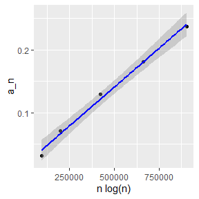

```r
ggplot(data = data.frame(t_n, a_n), aes(x = t_n, y = a_n)) +
  geom_point() +
  geom_smooth(method = "lm", color = "blue") +
  labs(x = "n log(n)",
       y = "a_n")
```

# HW 3

## Exercise 6.6

Estimate the 0.025, 0.05, 0.95, and 0.975 quantiles of the skewness $\sqrt{b_1}$ under normality by a Monte Carlo experiment. Compute the standard error of the estimates from (2.14) using the normal approximation for the density (with exact variance formula). Compare the estimated quantiles with the quantiles of the large sample approximation $\sqrt{b_1} \approx N(0, \frac{6}{n})$.

### Solution

随机变量 $X$ 的偏度为：

$$\sqrt{\beta_1} = \operatorname{E}\left[ \left( \frac{X - \mu}{\sigma}
\right)^3 \right]$$
使用蒙特卡洛模拟
$$\widehat{\sqrt{\beta_1}} = \frac{1}{n} \sum_{i=1}^{n} \left( \frac{X_i -
\hat{\mu}}{\hat{\sigma}} \right)^3$$

```r
n <- 1000  # 样本大小
t <- 10000  # 模拟次数

#蒙特卡洛模拟
skewness <- function(n,t) {
  skewness<- numeric(t)
  for (i in 1:t){
    x <- rnorm(n)
    mean_x <- mean(x)
    s <- sd(x)
    skewness[i] <- sum((x - mean_x)^3) / (n * s^3)
  }
  return(skewness)
}

b1_hat <- skewness(n,t)

# 计算偏度分位数
quant <- c(0.025, 0.05, 0.95, 0.975)
b1_hat_quant <- quantile(b1_hat, probs = quant)
#计算标准差
b1_density <- dnorm(b1_hat_quant, mean = 0, sd = sqrt(6/n))
b1_se <- sqrt(quant * (1 - quant) / (n * b1_density^2))
#大样本近似分位数
b1_quant <- qnorm(quant, mean = 0, sd = sqrt(6/n))

result <- matrix(1:12, nrow = 3, ncol = 4)
rownames(result) <- c('蒙特卡洛偏度分位数估计' , '标准误差', '大样本近似估计')
colnames(result) <- c("2.5%", "5%", "95%","97.5%")
for (i in 1:nrow(result)){
    if (i == 1){
    result[i,] <- b1_hat_quant}
    if (i == 2){
    result[i,] <- b1_se}
    if (i == 3){
    result[i,] <- b1_quant}
}
print(result)
```

```
##                                2.5%           5%         95%       97.5%
## 蒙特卡洛偏度分位数估计 -0.148337624 -0.124088944 0.128721653 0.153552195
## 标准误差                0.005997787  0.004828219 0.005323215 0.006838552
## 大样本近似估计         -0.151818157 -0.127409814 0.127409814 0.151818157
```

## Exercise 6.B

Tests for association based on Pearson product moment correlation $\rho$, Spearman’s rank correlation coefficient $\rho_s$, or Kendall’s coefficient $\tau$, are implemented in . Show (empirically) that the nonparametric tests based on $\rho_s$ or $\tau$ are less powerful than the correlation test when the sampled distribution is bivariate normal. Find an example of an alternative (a bivariate distribution $(X, Y)$ such that $X$ and $Y$ are dependent) such that at least one of the nonparametric tests has better empirical power than the correlation test against this alternative.

### Solution

```r
library(MASS)
n <- 100
t <- 1000
alpha <- 0.05
Sigma <- matrix(c(1, 0.3, 0.3, 1), ncol=2)#协方差阵
p_values <- matrix(NA, ncol=3, nrow=t)
#对多元正态分布
for (i in 1:t) {
    data <- mvrnorm(n=n, mu=c(0,0), Sigma=Sigma)
    # Pearson相关性检验
    p_values[i, 1] <- cor.test(data[,1], data[,2], method="pearson")$p.value
    # Spearman相关性检验
    p_values[i, 2] <- cor.test(data[,1], data[,2], method="spearman")$p.value
    # Kendall相关性检验
    p_values[i, 3] <- cor.test(data[,1], data[,2], method="kendall")$p.value
}
#计算检验功效
power <- colMeans(p_values < alpha)
names(power) <- c("Pearson", "Spearman", "Kendall")
print(power)
```

```
##  Pearson Spearman  Kendall
##    0.870    0.816    0.810
```

在多元正态分布下，皮尔逊检验表现最佳。

```r
#对非正态分布
#x为指数分布，y为x/3加上指数分布随机扰动
for (i in 1:t) {
  x <- rexp(n,1)
  y <- x/3 + rexp(n,1)
  data <- cbind(x,y)
  # Pearson相关性检验
  p_values[i, 1] <- cor.test(data[,1], data[,2], method="pearson")$p.value
  # Spearman相关性检验
  p_values[i, 2] <- cor.test(data[,1], data[,2], method="spearman")$p.value
  # Kendall相关性检验
  p_values[i, 3] <- cor.test(data[,1], data[,2], method="kendall")$p.value
}
power <- colMeans(p_values < alpha)
names(power) <- c("Pearson", "Spearman", "Kendall")
print(power)
```

```
##  Pearson Spearman  Kendall
##    0.880    0.953    0.964
```

在这种情况下，皮尔逊检验表现不佳。

## 3

If we obtain the powers for two methods under a particular simulation setting with 10,000 experiments: say, 0.651 for one method and 0.676 for another method. We want to know if the powers are different at 0.05 level.

What is the corresponding hypothesis test problem?

What test should we use? Z-test, two-sample t-test, paired-t test or McNemar test? Why?

Please provide the least necessary information for hypothesis testing.

### Answer

(1).原假设$H_0$:两个方法的功效没有显著差异。 备择假设$H_1$:两个方法的功效具有显著差异。

(2).假设题目意思是同一数据分别使用两种方法检验，应该使用配对t检验。Z检验假设检验统计量服从正态分布，适合样本量非常大的情况。 两样本t检验适用独立同分布的情况，功效比配对检验低。McNemar检验适用于二分类的离散数据。

(3)需提供两个方法的平均检验功效，方差，实验次数。

# HW 4

## EX1

```r
N <- 1000
n_null <- 950
n_alt <- 50
alpha <- 0.1
m <- 10000
set.seed(123)
results <- matrix(0, nrow = 3, ncol = 2)
colnames(results) <- c("Bonferroni correction", "B-H correction")
rownames(results) <- c("FWER", "FDR", "TPR")

#校正函数，返回FWER，FDR,TPR
correction <- function(p,method,alpha,n_null,n_alt){
  N=n_null+n_alt
  p_correction <- p.adjust(p,method=method)
  reject <- p_correction<alpha
  false_pos <- sum(reject[1:n_null])
  true_pos <- sum(reject[(n_null + 1):N])
  if (false_pos>0){FWER=1}
  else FWER=0
  FDR <- false_pos/sum(reject)
  TPR <- true_pos/n_alt
  return (c(FWER,FDR,TPR))
}

for (i in 1:m) {
  p_null <- runif(n_null)
  p_alt <- rbeta(n_alt, 0.1, 1)
  p_values <- c(p_null, p_alt)
  #bonferroni校正
  p_bf <- correction(p_values,"bonferroni",alpha,n_null,n_alt)
  results["FWER", "Bonferroni correction"] <- results["FWER", "Bonferroni correction"]+p_bf[1]
  results["FDR", "Bonferroni correction"] <- results["FDR", "Bonferroni correction"]+p_bf[2]
  results["TPR", "Bonferroni correction"] <- results["TPR", "Bonferroni correction"]+p_bf[3]

  # B-H校正
  p_bh <- correction(p_values,"BH",alpha,n_null,n_alt)
  results["FWER", "B-H correction"] <- results["FWER", "B-H correction"]+p_bh[1]
  results["FDR", "B-H correction"] <- results["FDR", "B-H correction"]+p_bh[2]
  results["TPR", "B-H correction"] <- results["TPR", "B-H correction"]+p_bh[3]
}

# 计算平均值
results["FWER", ] <- results["FWER", ] / m
results["FDR", ] <- results["FDR", ] / m
results["TPR", ] <- results["TPR", ] / m
print(results)
```

```
##      Bonferroni correction B-H correction
## FWER           0.087300000     0.93050000
## FDR            0.004510088     0.09502215
## TPR            0.396736000     0.56106200
```

Bonferroni校正对FDR特别严格，导致了优秀的FWER和FDR但是TPR表现较差。B-H则相反。

## EX2

```r
library(boot)
data <- c(3, 5, 7, 18, 43, 85, 91, 98, 100, 130, 230, 487)
#mle估计
mle_lambda <- 1 / mean(data)

lambda <- function(data, i) {
  return(1 / mean(data[i]))
}
# bootstrap估计
boot_results <- boot(data, lambda, R = 1000)
boot_bias <- mean(boot_results$t) - mle_lambda
boot_se <- sd(boot_results$t)
{
cat("最大似然估计 : ", mle_lambda, "\n")
cat("估计偏差: ", boot_bias, "\n")
cat("估计标准误差: ", boot_se, "\n")}
```

```
## 最大似然估计 :  0.00925212
## 估计偏差:  0.001522954
## 估计标准误差:  0.00455203
```

## EX3

```r
datamean <- function(x, i) mean(x[i])

de <- boot(data=data, statistic=datamean, R=1000)

ci <- boot.ci(de, type=c("norm", "basic", "perc", "bca"))
{
cat("standard normal CI: ", ci$norm[2:3], "\n")
cat("basic CI: ", ci$basic[4:5], "\n")
cat("percentile CI: ", ci$percent[4:5], "\n")
cat("BCa CI: ", ci$bca[4:5], "\n")}
```

```
## standard normal CI:  39.03054 179.7016
## basic CI:  29.18572 166.4979
## percentile CI:  49.66878 186.9809
## BCa CI:  60.41442 226.2589
```

获得的结果不同是因为几种方法基于的假设不同。normal基于正态假设，basic基于大样本，分位数基于条件分布相同，BCa校准了偏差。

# HW 5

## EX 7.8

```r
#清空内存
rm(list = ls())

library(boot)
library(bootstrap)
data(scor)

cov_matrix <- cov(scor)
eigenvalues <- eigen(cov_matrix)$values
theta_hat <- eigenvalues[1] / sum(eigenvalues)
#jacknife估计
jackknife <- function(data) {
  n <- nrow(data)
  theta_jack <- numeric(n)
  for (i in 1:n) {
    eigen_jack <- eigen(cov(data[-i, ]))$values
    theta_jack[i] <- eigen_jack[1] / sum(eigen_jack)
  }

  bias_jack <- (n - 1) * (mean(theta_jack) - theta_hat)
  se_jack <- sqrt((n - 1) * mean((theta_jack - theta_hat)^2))

   round(c(original=theta_hat,bias_jack=bias_jack,
 se_jack=se_jack),3)
}

jackknife_results <- jackknife(scor)
jackknife_results
```

```
##  original bias_jack   se_jack
##     0.619     0.001     0.050
```

## EX 7.10

```r
#清空内存
rm(list = ls())
library(DAAG)
data(ironslag)


magnetic <- ironslag$magnetic
chemical <- ironslag$chemical
n <- length(magnetic)

e1 <- e2 <- e3 <- e4 <- numeric(n)
for (k in 1:n) {
  y <- magnetic[-k]
  x <- chemical[-k]

  # 线性模型
  J1 <- lm(y ~ x)
  yhat1 <- J1$coef[1] + J1$coef[2] * chemical[k]
  e1[k] <- magnetic[k] - yhat1

  # 二次多项式模型
  J2 <- lm(y ~ x + I(x^2))
  yhat2 <- J2$coef[1] + J2$coef[2] * chemical[k] + J2$coef[3] * chemical[k]^2
  e2[k] <- magnetic[k] - yhat2

  # 对数-线性模型
  J3 <- lm(log(y) ~ x)
  logyhat3 <- J3$coef[1] + J3$coef[2] * chemical[k]
  yhat3 <- exp(logyhat3)
  e3[k] <- magnetic[k] - yhat3

  # 三次多项式模型
  J4 <- lm(y ~ x + I(x^2) + I(x^3))
  yhat4 <- J4$coef[1] + J4$coef[2] * chemical[k] +
           J4$coef[3] * chemical[k]^2 + J4$coef[4] * chemical[k]^3
  e4[k] <- magnetic[k] - yhat4
}

# 预测误差
pred_error <- array(c(mean(e1^2), mean(e2^2), mean(e3^2), mean(e4^2)),dim = c(1, 4))
colnames(pred_error) <- c("Linear", "Quadratic", "Log-Linear", "Cubic")
rownames(pred_error)<-c('prediction error')
pred_error
```

```
##                    Linear Quadratic Log-Linear    Cubic
## prediction error 19.55644  17.85248   18.44188 18.17756
```

```r
# 调整后的R^2
r2 <- array(c(summary(lm(magnetic ~ chemical))$adj.r.squared,
            summary(lm(magnetic ~ chemical + I(chemical^2)))$adj.r.squared,
            summary(lm(log(magnetic) ~ chemical))$adj.r.squared,
            summary(lm(magnetic ~ chemical + I(chemical^2) + I(chemical^3)))$adj.r.squared),dim=c(1,4))
colnames(r2) <- c("Linear", "Quadratic", "Log-Linear", "Cubic")
rownames(r2) <- c("adjusted R2")
r2
```

```
##                Linear Quadratic Log-Linear     Cubic
## adjusted R2 0.5281545 0.5768151  0.5280556 0.5740396
```

根据预测误差，选择二次函数模型；根据调整后的$R^2$，选择二次函数模型。

## EX 8.1

```r
#清空内存
rm(list = ls())
set.seed(123)
library(DAAG)
data(chickwts)
set.seed(123)
x <- sort(as.vector(chickwts$weight[chickwts$feed == "soybean"]))
y <- sort(as.vector(chickwts$weight[chickwts$feed == "linseed"]))

data <- c(x, y)
n_x <- length(x)
n_y <- length(y)
n <- n_x + n_y
R <- 1000
cv_stat <- numeric(R)

#Cramer-von Mises统计量
cvm <- function(data, indices) {
  x <- data[indices[1:n_x]]
  y <- data[indices[(n_x + 1):(n_x + n_y)]]
  ecdf_x <- ecdf(x)
  ecdf_y <- ecdf(y)
  W <- (1 / (n_x * n_y)) * sum((ecdf_x(data) - ecdf_y(data))^2)
  return(W)
}

boot_result <- boot(data,cvm, R)
W <- boot_result$t0
p_value <- mean(c(boot_result$t0,boot_result$t) >= W)


{cat("Cramer-von Mises统计量 W=", W, "\n")
cat("p值:", p_value, "\n")}
```

```
## Cramer-von Mises统计量 W= 0.00362913
## p值: 0.4095904
```

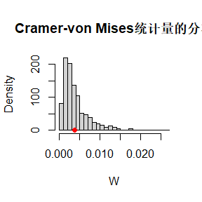

```r
hist(boot_result$t, main = "Cramer-von Mises统计量的分布",
     xlab = "W", freq = FALSE, breaks = "scott")
points(W, 0, cex = 1, pch = 16, col = "red")
```

接受分布相同。

## EX 8.2

```r
#清空内存
rm(list = ls())
library(boot)
# 生成数据
set.seed(123)
n <- 30
x <- rnorm(n)
y <- 0.1*x + rnorm(n)

# Spearman秩相关系数
spearman <- function(data, indices) {
  d <- data[indices, ]
  return(cor(d[, 1], d[, 2], method = "spearman"))
}

data <- data.frame(x, y)

R<- 10000
boot_results <- boot(data, spearman, R)
spearman_stat <- boot_results$t0
p_perm <- mean(abs(c(boot_results$t0,boot_results$t)) >= abs(boot_results$t0))
cor_test <- cor.test(x, y, method = "spearman")
{cat("置换检验的p值:", p_perm, "\n")
cat("cor.test 报告的p值:", cor_test$p.value, "\n")}
```

```
## 置换检验的p值: 0.7792221
## cor.test 报告的p值: 0.7456646
```

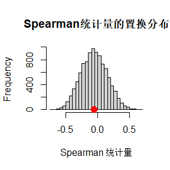

```r
# 绘制分布直方图
hist(boot_results$t, main = "Spearman统计量的置换分布", xlab = "Spearman 统计量", breaks = "scott")
points(spearman_stat, 0, cex = 1.5, pch = 16, col = "red")
```

# HW 6

## EX 9.3

```r
rm(list = ls())

target_pdf <- function(x) (1 / (pi * (1 + x^2)))#目标分布
n <- 1000000
set.seed(123)
# Metropolis-Hastings算法，采用正态作为提议分布
m_h <- function( n) {
  samples <- numeric(n+100000)
  samples[1] <- 0

  for (i in 2:n) {
    proposal <- rnorm(1, mean = samples[i - 1], sd = 1)
    accept_ratio <- target_pdf(proposal) / target_pdf(samples[i - 1])

    if (runif(1) < accept_ratio)  samples[i] <- proposal
    else  samples[i] <- samples[i - 1]
  }
  return(samples[-(1:100000)])#舍弃前1000个样本
}

samples <- m_h(n)


# 比较十分位数
{cat("生成样本的十分位数:\n")
print(quantile(samples,seq(0, 1, 0.1)))
cat("\n标准柯西分布的十分位数:\n")
print(qcauchy(seq(0, 1, 0.1)))}
```

```
## 生成样本的十分位数:
##           0%          10%          20%          30%          40%          50%
## -111.8609027   -3.0305244   -1.2783809   -0.6215036   -0.2112617    0.0000000
##          60%          70%          80%          90%         100%
##    0.1416581    0.5310911    1.1128279    2.4832217   75.7213686
##
## 标准柯西分布的十分位数:
##  [1]       -Inf -3.0776835 -1.3763819 -0.7265425 -0.3249197  0.0000000
##  [7]  0.3249197  0.7265425  1.3763819  3.0776835        Inf
```

```r
#Gelman-Rubin
chains <- list()
k=3
for (i in 1:k) {
  chains[[i]] <- m_h(n)
}

# 计算样本均值和方差
chain_means <- sapply(chains, mean)
chain_vars <- sapply(chains, var)
overall_mean <- mean(chain_means)

# 链间方差
B <- (n / (k - 1)) * sum((chain_means - overall_mean)^2)
# 链内方差
W <- mean(chain_vars)
# 总体方差
V <- ((n - 1) / n) * W + (1 / n) * B
R_hat <- sqrt(V / W)

if (R_hat < 1.2) {
  cat("链已收敛，R_hat=",R_hat,"\n")
} else {
  cat("链未收敛，R_hat=",R_hat,"\n")
}
```

```
## 链已收敛，R_hat= 1.00089
```

## EX 9.8

```r
rm(list = ls())
n <- 100
a <- 2
b <- 3
iter<- 5000
#初始化
x <- 1
y <- runif(1)

gibbs <- function(iter){
  results <- matrix(0, nrow = iter, ncol = 2)
  colnames(results) <- c("x", "y")
  for (i in 1:iter) {
    # 生成 x
    x <- rbinom(1, n, y)
    #生成 y
    results[i, ] <- c(x, y)
    y <- rbeta(1, x + a, n - x + b)
  }
  return(results[-(1:1000),])
}

#Gelman-Rubin
R_hat<-function(j){
  chains <- list()
  k=3
  for (i in 1:k) {
    chains[[i]] <- gibbs(iter)[ ,j]
  }
  chain_means <- sapply(chains, mean)
  chain_vars <- sapply(chains, var)
  overall_mean <- mean(chain_means)
  B <- (n / (k - 1)) * sum((chain_means - overall_mean)^2)
  W <- mean(chain_vars)
  V <- ((n - 1) / n) * W + (1 / n) * B
  R_hat <- sqrt(V / W)
  return(R_hat)
}


if (R_hat(1) < 1.2) {
  cat("链已收敛，R_hat(x),R_hat(y)=",c(R_hat(1),R_hat(2)),"\n")
} else {
  cat("链未收敛，R_hat(x),R_hat(y)=",c(R_hat(1),R_hat(2)),"\n")
}
```

```
## 链已收敛，R_hat(x),R_hat(y)= 1.001585 1.003013
```

## EX 3

设 $q_{ij} = g(x_{t+1} = j \mid x_t = i)$，M-H 抽样方法产生的样本序列 $x_0, x_1, \ldots$ 转移核为
$$p_{ij} = q_{ij} \alpha(i, j) + \delta_i(j) (1 - r(i))$$
其中 $r(i) = j \cdot q_{ij} \alpha(i, j)$，$\alpha(i, j) = \min\{1, \frac{f_j q_{ji}}{f_i q_{ij}}\}$，$\delta_i(j)$ 为 Dirac-delta 函数。

对$i \neq j$ 有
$$f_i q_{ij} \alpha(i, j) = f_i q_{ij} \min\{1, \frac{f_j q_{ji}}{f_i
q_{ij}}\} = f_j q_{ji} \min\{1, \frac{f_i q_{ij}}{f_j q_{ji}}\} = f_j
q_{ji}\alpha(j, i)$$
对 $i = j$
$$f_i \delta_i(j)(1 - r(i)) = f_j \delta_j(i)(1 - r(j))$$
从而满足细致平衡方程
$$p_{ij} f_i = p_{ji} f_j, \quad \forall i,j$$
因此 $f$ 为该链的平稳分布。

# HW 7

## Ex 11.3

#### (a)

```r
#清空内存
rm(list = ls())
k_term <- function(k, a, d) {
  #取对数
  term_log <-  - (lgamma(k + 1) + k * log(2)) +
              (2 * k + 2) * log(sqrt(sum(a^2))) - log(2 * k + 1) - log(2 * k + 2) +
              lgamma((d + 1) / 2) + lgamma(k + 1.5) - lgamma(k + d / 2 + 1)
  term <- (-1)^k*exp(term_log)
  return(term)
}
```

#### (b)

```r
function_sum <- function(a, d) {
  sum_result <- 0
  k<- 0:100
  term_log <-  - (lgamma(k + 1) + k * log(2)) +
              (2 * k + 2) * log(sqrt(sum(a^2))) - log(2 * k + 1) - log(2 * k + 2) +
              lgamma((d + 1) / 2) + lgamma(k + 1.5) - lgamma(k + d / 2 + 1)
  term <- (-1)^k*exp(term_log)
  return(sum(term))
}
```

#### (c)

```r
a <- c(1, 2)
d <- length(a)
result <- function_sum(a, d)
print(result)
```

```
## [1] 1.532164
```

## Ex 11.5

```r
#清空内存
rm(list = ls())
c_k <- function(a,k) {
  sqrt(a^2 * k / (k + 1 - a^2))
}

lhs <- function(a,k){
   2 * exp(lgamma(k / 2)-lgamma((k - 1) / 2)) / sqrt(pi * (k - 1))  * integrate(function(u) (1 + u^2 / (k - 1))^(-k / 2), 0, c_k(a,k-1))$value
}

rhs <- function(a,k){
  2 * exp(lgamma((k+1) / 2)-lgamma(k/ 2)) / sqrt(pi * k) * integrate(function(u) (1 + u^2 / k)^(-(k + 1) / 2), 0, c_k(a,k))$value
}



solve_a <- function(k) {
  # 方程的解
  f <- function(a) {
    lhs(a,k)-rhs(a,k)
  }

  # 使用 uniroot 求解
  solution_a <- uniroot(f, lower = 0.1, upper = min(sqrt(k),2))$root
  return(solution_a)
}

k_values <- c(4:25, 100, 500, 1000)
solution <- sapply(k_values, solve_a)
print(rbind(k_values,solution))
```

```
##              [,1]     [,2]     [,3]     [,4]     [,5]     [,6]      [,7]
## k_values 4.000000 5.000000 6.000000 7.000000 8.000000 9.000000 10.000000
## solution 1.492105 1.533557 1.562758 1.584409 1.601192 1.614519  1.625385
##               [,8]      [,9]     [,10]    [,11]     [,12]     [,13]     [,14]
## k_values 11.000000 12.000000 13.000000 14.00000 15.000000 16.000000 17.000000
## solution  1.634412  1.642028  1.648543  1.65418  1.659105  1.663444  1.667296
##              [,15]     [,16]     [,17]     [,18]     [,19]     [,20]     [,21]
## k_values 18.000000 19.000000 20.000000 21.000000 22.000000 23.000000 24.000000
## solution  1.670738  1.673834  1.676632  1.679173  1.681492  1.683616  1.685569
##             [,22]      [,23]      [,24]       [,25]
## k_values 25.00000 100.000000 500.000000 1000.000000
## solution  1.68737   1.720607   1.729753    1.730905
```

```r
#清空内存
rm(list = ls())
S_k1 <- function(a, k) {
  1 - pt(sqrt(a^2 * (k - 1) / (k - a^2)), df = k - 1)
}
S_k <- function(a, k) {
  1 - pt(sqrt(a^2 * k / (k + 1 - a^2)), df = k)
}

solve_a <- function(k) {
  # 方程的解
  f <- function(a) {
    S_k1(a,k)-S_k(a,k)
  }

  # 使用 uniroot 求解
  solution_a <- uniroot(f, lower = 0.1, upper = min(sqrt(k),2))$root
  return(solution_a)
}

k_values <- c(4:25, 100, 500, 1000)
solution <- sapply(k_values, solve_a)
print(rbind(k_values,solution))
```

```
##              [,1]     [,2]     [,3]     [,4]     [,5]     [,6]      [,7]
## k_values 4.000000 5.000000 6.000000 7.000000 8.000000 9.000000 10.000000
## solution 1.492105 1.533557 1.562758 1.584409 1.601192 1.614519  1.625385
##               [,8]      [,9]     [,10]    [,11]     [,12]     [,13]     [,14]
## k_values 11.000000 12.000000 13.000000 14.00000 15.000000 16.000000 17.000000
## solution  1.634412  1.642028  1.648543  1.65418  1.659105  1.663444  1.667296
##              [,15]     [,16]     [,17]     [,18]     [,19]     [,20]     [,21]
## k_values 18.000000 19.000000 20.000000 21.000000 22.000000 23.000000 24.000000
## solution  1.670738  1.673834  1.676632  1.679173  1.681492  1.683616  1.685569
##             [,22]      [,23]      [,24]       [,25]
## k_values 25.00000 100.000000 500.000000 1000.000000
## solution  1.68737   1.720607   1.729753    1.730905
```

可以发现解相同。

## 3

```r
observed_data <- c(0.54, 0.48, 0.33, 0.43, 1.00, 1.00, 0.91, 1.00, 0.21, 0.85)
tau <- 1
n <- length(observed_data)

# E-M 算法
em <- function(data, tau, tol = 1e-6, max_iter = 1000) {
  # 初始化 lambda
  lambda <- 1 / mean(data)  # 初始值

  for (i in 1:max_iter) {
    # E步
    truncated_data <- data[data == tau]
    untruncated_data <- data[data < tau]
    expected_truncated <- sum(truncated_data + 1 / lambda)

    # M步
    lambda_new <- n / (sum(untruncated_data) + expected_truncated)

    if (abs(lambda - lambda_new) < tol) break
    lambda <- lambda_new
  }
  return(lambda)
}

lambda_em <- em(observed_data, tau)

# 使用观测数据直接计算 MLE
log_likelihood <- function(lambda) {
  -sum(ifelse(observed_data < tau, log(lambda) - lambda * observed_data, -lambda * tau))
}
mle_result <- optim(par = 1, log_likelihood, method = "Brent", lower = 1e-5, upper = 10)
lambda_mle<- mle_result$par


# 输出结果
cat("EM 算法估计的 λ:", lambda_em, "\n")
```

```
## EM 算法估计的 λ: 1.037038
```

```r
cat("MLE 估计的 λ:", lambda_mle, "\n")
```

```
## MLE 估计的 λ: 1.037037
```

# HW 8

## Exercises 11.7

```r
#清空内存
rm(list = ls())
library(boot)
# 定义约束
A1 <- rbind(c(2, 1, 1),  # 2x + y + z <= 2
            c(1, -1, 3)) # x - y + 3z <= 3
b1 <- c(2, 3)
a <- c(4, 2, 9)

# simplex
result <- simplex(a = a, A1 = A1, b1 = b1, maxi = FALSE)

cat("最优解的值为:\n")
```

```
## 最优解的值为:
```

```r
print(result$soln)
```

```
## x1 x2 x3
##  0  0  0
```

```r
cat("目标函数的最小值为:\n")
```

```
## 目标函数的最小值为:
```

```r
print(result$value)
```

```
## b
## 0
```

## Exercises 3, 4, 5

```r
#清空内存
rm(list = ls())

formulas <- list(
mpg ~ disp,
mpg ~ I(1 / disp),
mpg ~ disp + wt,
mpg ~ I(1 / disp) + wt
)
model_1 <- lapply(formulas, function(f) lm(f, data = mtcars))
print(model_1)
```

```
## [[1]]
##
## Call:
## lm(formula = f, data = mtcars)
##
## Coefficients:
## (Intercept)         disp
##    29.59985     -0.04122
##
##
## [[2]]
##
## Call:
## lm(formula = f, data = mtcars)
##
## Coefficients:
## (Intercept)    I(1/disp)
##       10.75      1557.67
##
##
## [[3]]
##
## Call:
## lm(formula = f, data = mtcars)
##
## Coefficients:
## (Intercept)         disp           wt
##    34.96055     -0.01772     -3.35083
##
##
## [[4]]
##
## Call:
## lm(formula = f, data = mtcars)
##
## Coefficients:
## (Intercept)    I(1/disp)           wt
##      19.024     1142.560       -1.798
```

```r
bootstraps <- lapply(1:10, function(i) {
rows <- sample(1:nrow(mtcars), rep = TRUE)
mtcars[rows, ]
})
fit_model <- function(data) {
  lm(mpg ~ disp, data = data)
}

model_2 <- lapply(bootstraps, fit_model)
print(model_2)
```

```
## [[1]]
##
## Call:
## lm(formula = mpg ~ disp, data = data)
##
## Coefficients:
## (Intercept)         disp
##    28.71376     -0.04173
##
##
## [[2]]
##
## Call:
## lm(formula = mpg ~ disp, data = data)
##
## Coefficients:
## (Intercept)         disp
##    30.49773     -0.04302
##
##
## [[3]]
##
## Call:
## lm(formula = mpg ~ disp, data = data)
##
## Coefficients:
## (Intercept)         disp
##    30.61239     -0.04535
##
##
## [[4]]
##
## Call:
## lm(formula = mpg ~ disp, data = data)
##
## Coefficients:
## (Intercept)         disp
##    27.01433     -0.03283
##
##
```

[output cut: 43 more lines]

```
## lm(formula = mpg ~ disp, data = data)
##
## Coefficients:
## (Intercept)         disp
##    27.34255     -0.03497
##
##
## [[10]]
##
## Call:
## lm(formula = mpg ~ disp, data = data)
##
## Coefficients:
## (Intercept)         disp
##    31.02192     -0.04474
```

```r
rsq <- function(mod) summary(mod)$r.squared
r2_lapply <- sapply(c(model_1,model_2), rsq)

# 输出 R^2 值
print(r2_lapply)
```

```
##  [1] 0.7183433 0.8596865 0.7809306 0.8838038 0.7582499 0.7646900 0.6918616
##  [8] 0.7622333 0.7554079 0.7741622 0.7248167 0.6312012 0.7147688 0.7411546
```

## Exercise 3

```r
#清空内存
rm(list = ls())
trials <- replicate(
  100,
  t.test(rpois(10, 10), rpois(7, 10)),
  simplify = FALSE
)

p_values <- sapply(trials, function(x) x$p.value)
print(p_values)
```

```
##   [1] 0.780353325 0.891190181 0.599938405 0.343752020 0.279195877 0.611148680
##   [7] 0.898829396 0.896800012 0.540163347 0.217484078 0.434702980 0.363104396
##  [13] 0.109385331 0.695410309 0.519378769 0.591360111 0.033844990 0.789436660
##  [19] 0.047018163 0.725563187 0.021389546 0.833207747 0.054591132 0.370989228
##  [25] 0.003574069 0.022363195 0.087207641 0.380950867 0.361682948 0.831476728
##  [31] 0.838938640 0.351213553 0.424271596 0.991209872 0.266202557 0.876501693
##  [37] 0.881539177 0.605877592 0.916576280 0.793682801 0.567905491 0.155356325
##  [43] 0.694546071 0.730850233 0.769606301 0.928583736 0.572032830 0.894035728
##  [49] 0.591915810 0.269217528 0.354298170 0.200432829 0.146327429 0.429241579
##  [55] 0.435267213 0.684266403 0.010553233 0.827351276 0.520315281 0.683446318
##  [61] 0.774215284 0.860724992 0.534381421 0.940734435 0.896415817 0.383952850
##  [67] 0.455849270 0.672284006 0.613249775 0.944933606 0.327013695 0.190832238
##  [73] 0.220570747 0.082076299 0.426348646 0.679361739 0.605928603 0.161899137
##  [79] 0.754938576 0.330809776 0.670883358 0.324750703 0.671054058 0.096213538
##  [85] 0.116192493 0.631499197 0.923458128 0.625103006 0.310992379 0.072051489
##  [91] 0.946959703 0.363162344 0.353276102 0.464929786 0.270480616 0.305997550
##  [97] 0.824328084 0.715013272 0.318526381 0.958316422
```

## Exercise 3

```r
p_values <- sapply(trials, `[[`, "p.value")
print(p_values)
```

```
##   [1] 0.780353325 0.891190181 0.599938405 0.343752020 0.279195877 0.611148680
##   [7] 0.898829396 0.896800012 0.540163347 0.217484078 0.434702980 0.363104396
##  [13] 0.109385331 0.695410309 0.519378769 0.591360111 0.033844990 0.789436660
##  [19] 0.047018163 0.725563187 0.021389546 0.833207747 0.054591132 0.370989228
##  [25] 0.003574069 0.022363195 0.087207641 0.380950867 0.361682948 0.831476728
##  [31] 0.838938640 0.351213553 0.424271596 0.991209872 0.266202557 0.876501693
##  [37] 0.881539177 0.605877592 0.916576280 0.793682801 0.567905491 0.155356325
##  [43] 0.694546071 0.730850233 0.769606301 0.928583736 0.572032830 0.894035728
##  [49] 0.591915810 0.269217528 0.354298170 0.200432829 0.146327429 0.429241579
##  [55] 0.435267213 0.684266403 0.010553233 0.827351276 0.520315281 0.683446318
##  [61] 0.774215284 0.860724992 0.534381421 0.940734435 0.896415817 0.383952850
##  [67] 0.455849270 0.672284006 0.613249775 0.944933606 0.327013695 0.190832238
##  [73] 0.220570747 0.082076299 0.426348646 0.679361739 0.605928603 0.161899137
##  [79] 0.754938576 0.330809776 0.670883358 0.324750703 0.671054058 0.096213538
##  [85] 0.116192493 0.631499197 0.923458128 0.625103006 0.310992379 0.072051489
##  [91] 0.946959703 0.363162344 0.353276102 0.464929786 0.270480616 0.305997550
##  [97] 0.824328084 0.715013272 0.318526381 0.958316422
```

```r
#清空内存
rm(list = ls())
parallel_lapply <- function(FUN, x,y, output_type) {
  results <- Map(FUN, x,y)
  vapply(results, identity, output_type)
}

a <- c(1, 2, 3)
b <- c(4, 5, 6)
output <- parallel_lapply(function(x, y) x + y, a, b, numeric(1))
print(output)
```

```
## [1] 5 7 9
```

参数有函数，输入的数组，输出的格式.

## Exercise 4

```r
#清空内存
rm(list = ls())
fast_chisq_test <- function(x, y) {

  #列联表
  contingency_table <- table(x, y)
  row_sum <- rowSums(contingency_table)
  col_sum <- colSums(contingency_table)
  total_sample_size <- sum(contingency_table)

  #计算
  theoretical_frequency <- outer(row_sum, col_sum) / total_sample_size
  chisq_statistic <- sum((contingency_table - theoretical_frequency)^2 / theoretical_frequency)
  df <- (nrow(contingency_table) - 1) * (ncol(contingency_table) - 1)
  p_value <- pchisq(chisq_statistic, df, lower.tail = FALSE)

  return(list(p_value = p_value))
}

x <- c(1,2,3,1,2,3)
y <- c(3,2,1,3,2,1)
result <- fast_chisq_test(x, y)
print(result)
```

```
## $p_value
## [1] 0.01735127
```

## Exercise 5

```r
#清空内存
rm(list = ls())
fast_table <- function(x, y) {

  #获得观测值范围
  x_vals <- sort(unique(x))
  y_vals <- sort(unique(y))
  contingency_matrix <- matrix(0, nrow = length(x_vals), ncol = length(y_vals),
                               dimnames = list(x_vals, y_vals))

  x_indices <- match(x, x_vals)
  y_indices <- match(y, y_vals)
  for (i in seq_along(x)) {
    contingency_matrix[x_indices[i], y_indices[i]] <- contingency_matrix[x_indices[i], y_indices[i]] + 1
  }

  return(contingency_matrix)
}

fast_chisq_test <- function(x, y) {

  #列联表
  contingency_table <- fast_table(x, y)
  row_sum <- rowSums(contingency_table)
  col_sum <- colSums(contingency_table)
  total_sample_size <- sum(contingency_table)

  #计算
  theoretical_frequency <- outer(row_sum, col_sum) / total_sample_size
  chisq_statistic <- sum((contingency_table - theoretical_frequency)^2 / theoretical_frequency)
  df <- (nrow(contingency_table) - 1) * (ncol(contingency_table) - 1)
  p_value <- pchisq(chisq_statistic, df, lower.tail = FALSE)

  return(list(p_value = p_value))
}

x <- c(1,2,3,1,2,3)
y <- c(3,2,1,3,2,1)
result <- fast_chisq_test(x, y)
print(result)
```

```
## $p_value
## [1] 0.01735127
```

# HW 9

```r
#清空内存
rm(list = ls())
library(Rcpp)
```

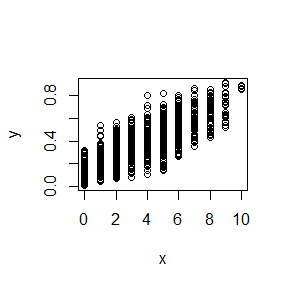

```r
library(ggplot2)

#Rcpp
cppFunction('
#include <Rcpp.h>
using namespace Rcpp;

// [[Rcpp::export]]
NumericMatrix gibbs_sampler(int n, int a, int b,  int N) {
    NumericMatrix samples(N, 2); // 存储结果
    double x = 0; // 初始化 x
    double y = 1; // 初始化 y

    for (int i = 0; i < N; ++i) {// Gibbs采样
        x = R::rbinom(n, y);
        y = R::rbeta(x + a, n - x + b);
        samples(i, 0) = x;
        samples(i, 1) = y;
    }
    return samples;
}
')
n <- 10
a <- 2
b <- 3
N <- 1000
#生成数据与绘图
set.seed(123)
samples <- gibbs_sampler(n, a, b, N)
plot(samples,xlab="x", ylab="y")
```

```r
gibbs_sampler_r <- function(n, a, b, num_steps) {
  x <- 0
  y <- 1
  samples <- matrix(0, nrow = num_steps, ncol = 2)
  # Gibbs采样
  for (i in 1:num_steps) {
    x <- rbinom(1, size = n, prob = y)
    y <- rbeta(1, shape1 = x + a, shape2 = n - x + b)
    samples[i, ] <- c(x, y)
  }
  samples
}
set.seed(123)
samples_rcpp <- gibbs_sampler(n, a, b, N)
set.seed(123)
samples_r <- gibbs_sampler_r(n, a, b, N)
```

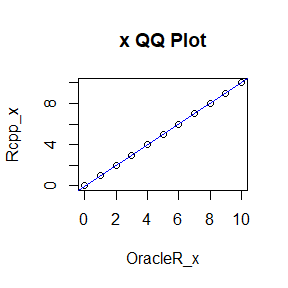

```r
# 比较QQ图
qqplot(
  samples_r[,1], samples_rcpp[,1],
  main = "x QQ Plot",
  xlab = "OracleR_x",
  ylab = "Rcpp_x"
)
abline(0, 1, col = "blue")
```

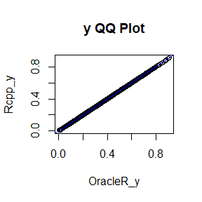

```r
# QQ plot comparison for y
qqplot(
  samples_r[,2], samples_rcpp[,2],
  main = "y QQ Plot",
  xlab = "OracleR_y",
  ylab = "Rcpp_y"
)
abline(0, 1, col = "blue")
```

```r
library(microbenchmark)
#比较运行时间
benchmark_results <- microbenchmark(
  samples_rcpp <- gibbs_sampler(n, a, b, N),
  samples_r <- gibbs_sampler_r(n, a, b, N),
  times = 100
)
print(benchmark_results)
```

```
## Unit: microseconds
##                                       expr    min      lq     mean median
##  samples_rcpp <- gibbs_sampler(n, a, b, N)  155.3  163.00  171.614  168.6
##   samples_r <- gibbs_sampler_r(n, a, b, N) 1354.4 1422.55 2306.605 1461.0
##       uq     max neval
##   174.05   296.3   100
##  1542.10 83391.6   100
```

从QQ图中可以发现使用rcpp编写的Gibbs算法与自带的算法给出的结果相似。rcpp运算耗时在自带算法的1/10左右。